# Term_project_ppt

# Data Introduction

## 資料來源:

[Concrete Compressive Strength Data Set, UCI Machine Learning Repository](http://archive.ics.uci.edu/ml/datasets/concrete+compressive+strength)

## 變數介紹

- 8 項與混凝土抗壓強度有關的解釋變數($X_i$):
  1. Cement: 水泥
  2. Blast Furnace Slag: 高爐渣, 簡稱 BFS →高爐煉鐵過程中排出的渣
  3. Fly Ash: 飛灰, 簡稱 FlyAsh →發電廠燒煤時的廢棄物
  4. Water: 水
  5. Superplasticizer: 塑化劑, 簡稱 SP →增加材料的柔軟性或使材料液化的添加劑
  6. Coarse Aggregate: 粗骨材, 簡稱 CA →一般為天然石或者為人造石
  7. Fine Aggregate: 细骨料, 簡稱 FA →一般為天然砂或者人造砂
  8. Age: 製造天數
- 被解釋變數($Y$):
  1. Concrete compressive strength: 混凝土抗壓強度, 簡稱 CCS
- 共1030筆觀察值

## 研究問題

我們想了解哪些因素和混凝土抗壓強度有關。

# Data Visualization I

首先我們畫出所有變數的 density plot。

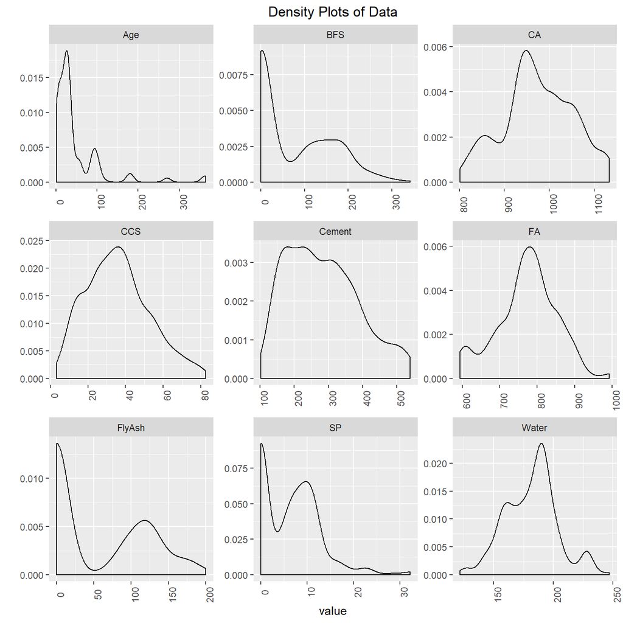

# Data Visualization II

接著我們畫出所有變數的 correlation coefficient plot。

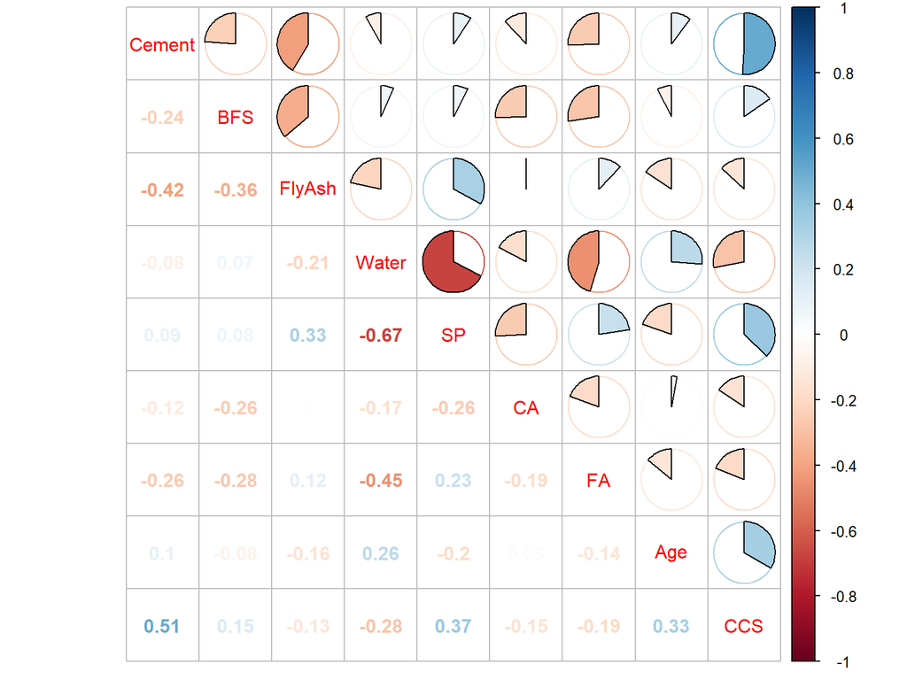

# Split data

我們將 1030 筆資料切分成 515 筆 train data 以及 515 筆 test data，並利用 train data 進行模型挑選。

# Model Selection I

## Stepwise function

我們的 Stepwise 方向為 both ，挑選的 criterion 為 AIC， 此階段挑選出兩個可行模型。

1. $CCS = Cement + BFS + FlyAsh + Water + SP + Age + \epsilon$
2. $CCS = Cement + BFS + FlyAsh + Water + Age + \epsilon$

```
## Start:  AIC=2415.65
## CCS ~ Cement + BFS + FlyAsh + Water + SP + CA + FA + Age
##
##          Df Sum of Sq   RSS    AIC
## <none>                54165 2415.7
## - FA      1     230.8 54396 2415.8
## - CA      1     297.4 54462 2416.5
## - Water   1     386.8 54552 2417.3
## - SP      1     765.1 54930 2420.9
## - FlyAsh  1    3579.1 57744 2446.6
## - BFS     1    6576.3 60741 2472.7
## - Cement  1   11788.6 65954 2515.1
## - Age     1   24079.9 78245 2603.1
```

```
##
## Call:
## lm(formula = CCS ~ Cement + BFS + FlyAsh + Water + SP + CA +
##     FA + Age, data = r.model)
##
## Coefficients:
## (Intercept)       Cement          BFS       FlyAsh        Water
##   -38.20926      0.12270      0.11068      0.09909     -0.10618
##          SP           CA           FA          Age
##     0.34421      0.02143      0.02185      0.11000
```

```
## Start:  AIC=2415.83
## CCS ~ Cement + BFS + FlyAsh + Water + SP + CA + Age
##
##          Df Sum of Sq   RSS    AIC
## - CA      1        69 54465 2414.5
## <none>                54396 2415.8
## - SP      1       632 55028 2419.8
## - Water   1      2870 57265 2440.3
## - FlyAsh  1      5463 59858 2463.1
## - BFS     1     16358 70754 2549.2
## - Age     1     23920 78315 2601.5
## - Cement  1     33614 88010 2661.6
##
## Step:  AIC=2414.49
## CCS ~ Cement + BFS + FlyAsh + Water + SP + Age
##
##          Df Sum of Sq   RSS    AIC
## <none>                54465 2414.5
## - SP      1       566 55031 2417.8
## - Water   1      4184 58649 2450.6
## - FlyAsh  1      5393 59858 2461.1
## - BFS     1     16877 71342 2551.5
## - Age     1     24171 78636 2601.6
## - Cement  1     34597 89062 2665.8
```

```
##
## Call:
## lm(formula = CCS ~ Cement + BFS + FlyAsh + Water + SP + Age,
##     data = r.model)
##
## Coefficients:
## (Intercept)       Cement          BFS       FlyAsh        Water
##    21.19614      0.10698      0.09164      0.07901     -0.18443
##          SP          Age
##     0.26632      0.10989
```

```
## Start:  AIC=2414.49
## CCS ~ Cement + BFS + FlyAsh + Water + SP + Age
##
##          Df Sum of Sq   RSS    AIC
## <none>                54465 2414.5
## - SP      1       566 55031 2417.8
## - Water   1      4184 58649 2450.6
## - FlyAsh  1      5393 59858 2461.1
## - BFS     1     16877 71342 2551.5
## - Age     1     24171 78636 2601.6
## - Cement  1     34597 89062 2665.8
```

```
##
## Call:
## lm(formula = CCS ~ Cement + BFS + FlyAsh + Water + SP + Age,
##     data = r.model)
##
## Coefficients:
## (Intercept)       Cement          BFS       FlyAsh        Water
##    21.19614      0.10698      0.09164      0.07901     -0.18443
##          SP          Age
##     0.26632      0.10989
```

# Model Selection II

```
##
## Call:
## lm(formula = CCS ~ Cement + BFS + FlyAsh + Water + SP + Age,
##     data = r.model)
##
## Residuals:
##      Min       1Q   Median       3Q      Max
## -27.4282  -6.6153   0.6276   7.0534  26.1010
##
## Coefficients:
##              Estimate Std. Error t value Pr(>|t|)
## (Intercept) 21.196144   5.881301   3.604 0.000344 ***
## Cement       0.106982   0.005956  17.963  < 2e-16 ***
## BFS          0.091637   0.007304  12.546  < 2e-16 ***
## FlyAsh       0.079014   0.011141   7.092 4.44e-12 ***
## Water       -0.184434   0.029524  -6.247 8.87e-10 ***
## SP           0.266319   0.115900   2.298 0.021977 *
## Age          0.109894   0.007319  15.015  < 2e-16 ***
## ---
## Signif. codes:  0 '***' 0.001 '**' 0.01 '*' 0.05 '.' 0.1 ' ' 1
##
## Residual standard error: 10.35 on 508 degrees of freedom
## Multiple R-squared:  0.6231, Adjusted R-squared:  0.6186
## F-statistic:   140 on 6 and 508 DF,  p-value: < 2.2e-16
```

```
## [1] 223.0216
```

```
## Analysis of Variance Table
##
## Response: CCS
##            Df Sum Sq Mean Sq  F value    Pr(>F)
## Cement      1  37562   37562 350.3405 < 2.2e-16 ***
## BFS         1  11514   11514 107.3903 < 2.2e-16 ***
## FlyAsh      1  11106   11106 103.5851 < 2.2e-16 ***
## Water       1   4832    4832  45.0646  5.11e-11 ***
## SP          1    848     848   7.9114  0.005103 **
## Age         1  24171   24171 225.4456 < 2.2e-16 ***
## Residuals 508  54465     107
## ---
## Signif. codes:  0 '***' 0.001 '**' 0.01 '*' 0.05 '.' 0.1 ' ' 1
```

```
##
## Call:
## lm(formula = CCS ~ Cement + BFS + FlyAsh + Water + Age, data = r.model)
##
## Residuals:
##      Min       1Q   Median       3Q      Max
## -27.5463  -6.7113   0.8617   6.9295  26.9976
##
## Coefficients:
##              Estimate Std. Error t value Pr(>|t|)
## (Intercept) 28.074549   5.083757   5.522 5.34e-08 ***
## Cement       0.112254   0.005519  20.340  < 2e-16 ***
## BFS          0.098891   0.006614  14.952  < 2e-16 ***
## FlyAsh       0.091582   0.009746   9.397  < 2e-16 ***
## Water       -0.228054   0.022708 -10.043  < 2e-16 ***
## Age          0.110468   0.007345  15.039  < 2e-16 ***
## ---
## Signif. codes:  0 '***' 0.001 '**' 0.01 '*' 0.05 '.' 0.1 ' ' 1
##
## Residual standard error: 10.4 on 509 degrees of freedom
## Multiple R-squared:  0.6192, Adjusted R-squared:  0.6154
## F-statistic: 165.5 on 5 and 509 DF,  p-value: < 2.2e-16
```

```
## [1] 111.5243
```

```
## Analysis of Variance Table
##
## Response: CCS
##            Df Sum Sq Mean Sq F value    Pr(>F)
## Cement      1  37562   37562 347.419 < 2.2e-16 ***
## BFS         1  11514   11514 106.495 < 2.2e-16 ***
## FlyAsh      1  11106   11106 102.721 < 2.2e-16 ***
## Water       1   4832    4832  44.689 6.085e-11 ***
## Age         1  24453   24453 226.175 < 2.2e-16 ***
## Residuals 509  55031     108
## ---
## Signif. codes:  0 '***' 0.001 '**' 0.01 '*' 0.05 '.' 0.1 ' ' 1
```

# Model Selection III

- $m_0: CCS = Cement + BFS + FlyAsh + Water + Age + \epsilon$

我們原始的模型為$m_0$，首先 fit $m_0$ 後畫出殘差圖:

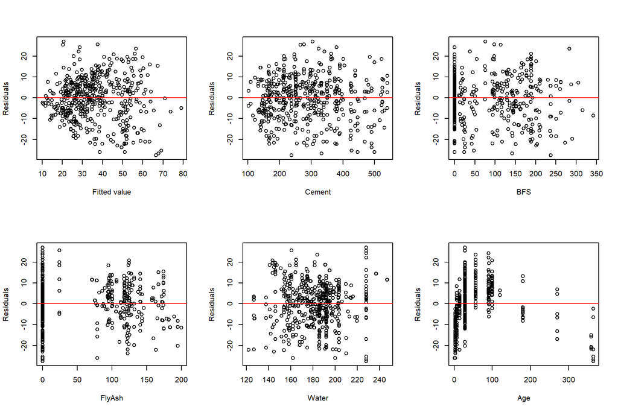

從上面的殘差圖，可以看出兩項問題:

1. 由$\widehat{y_{m_0}}$ 對殘差的scatter plot可以看出變異數可能不同值的現象。
2. 由$Age$ 對殘差的scatter plot可以看出製造天數可能和CCS可能有非線性關係。

- $m_1: \sqrt{CCS} = Cement + BFS + FlyAsh + Water + Age + \epsilon$

```
##
## Call:
## lm(formula = sqrt.CCS ~ ., data = data1)
##
## Residuals:
##     Min      1Q  Median      3Q     Max
## -2.5201 -0.6452  0.1451  0.6987  2.3642
##
## Coefficients:
##               Estimate Std. Error t value Pr(>|t|)
## (Intercept)  4.7729553  0.4477286  10.660   <2e-16 ***
## Cement       0.0097706  0.0004860  20.102   <2e-16 ***
## BFS          0.0082856  0.0005825  14.224   <2e-16 ***
## FlyAsh       0.0086329  0.0008583  10.058   <2e-16 ***
## Water       -0.0179630  0.0019999  -8.982   <2e-16 ***
## Age          0.0097460  0.0006469  15.065   <2e-16 ***
## ---
## Signif. codes:  0 '***' 0.001 '**' 0.01 '*' 0.05 '.' 0.1 ' ' 1
##
## Residual standard error: 0.9157 on 509 degrees of freedom
## Multiple R-squared:  0.6045, Adjusted R-squared:  0.6006
## F-statistic: 155.6 on 5 and 509 DF,  p-value: < 2.2e-16
```

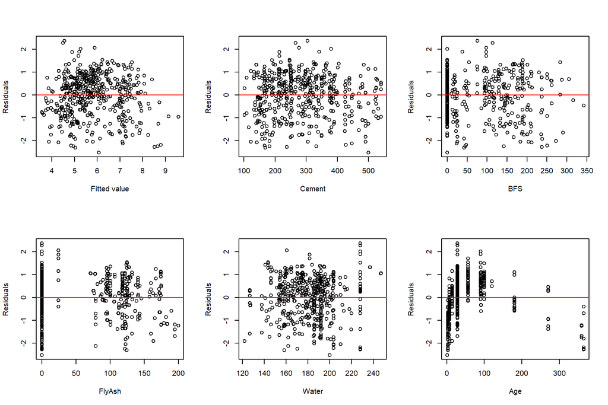

接著我們針對問題 2，在模型中加入$Age^2$，不過無助於解決Age對於CCS的非線性問題，可由下面的殘差圖得知。

- $m_2: \sqrt{CCS} = Cement + BFS + FlyAsh + Water + Age + Age^2 + \epsilon$

```
##
## Call:
## lm(formula = sqrt.CCS ~ ., data = data1s.c)
##
## Residuals:
##      Min       1Q   Median       3Q      Max
## -2.05013 -0.49953  0.04523  0.53764  2.26129
##
## Coefficients:
##               Estimate Std. Error t value Pr(>|t|)
## (Intercept)  5.813e+00  3.316e-02  175.30   <2e-16 ***
## Cement       9.573e-03  3.996e-04   23.95   <2e-16 ***
## BFS          8.349e-03  4.787e-04   17.44   <2e-16 ***
## FlyAsh       7.861e-03  7.071e-04   11.12   <2e-16 ***
## Water       -1.677e-02  1.645e-03  -10.19   <2e-16 ***
## Age          3.011e-02  1.404e-03   21.45   <2e-16 ***
## `Age^2`     -6.888e-05  4.395e-06  -15.67   <2e-16 ***
## ---
## Signif. codes:  0 '***' 0.001 '**' 0.01 '*' 0.05 '.' 0.1 ' ' 1
##
## Residual standard error: 0.7526 on 508 degrees of freedom
## Multiple R-squared:  0.7334, Adjusted R-squared:  0.7302
## F-statistic: 232.9 on 6 and 508 DF,  p-value: < 2.2e-16
```

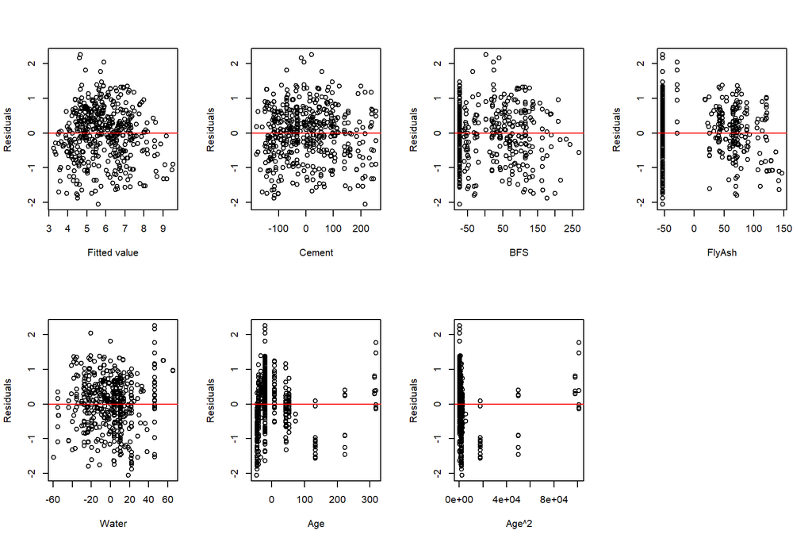

最後，我們加入$\sqrt{Age}$，得到模型$m_3$

- $m_3: \sqrt{CCS} = Cement + BFS + FlyAsh + Water + Age + \sqrt{Age} + \epsilon$

由於加入$\sqrt(Age)$，我們把模型中的變量做centering處理。

```
##
## Call:
## lm(formula = CCS ~ Cement + BFS + FlyAsh + Water + Age + sqrt.Age,
##     data = data2.c)
##
## Residuals:
##      Min       1Q   Median       3Q      Max
## -1.63866 -0.35144 -0.00744  0.40422  1.88074
##
## Coefficients:
##               Estimate Std. Error t value Pr(>|t|)
## (Intercept)  5.8133470  0.0269452  215.75   <2e-16 ***
## Cement       0.0096109  0.0003246   29.61   <2e-16 ***
## BFS          0.0076931  0.0003897   19.74   <2e-16 ***
## FlyAsh       0.0064257  0.0005798   11.08   <2e-16 ***
## Water       -0.0163352  0.0013370  -12.22   <2e-16 ***
## Age         -0.0224541  0.0013502  -16.63   <2e-16 ***
## sqrt.Age     0.6052138  0.0240445   25.17   <2e-16 ***
## ---
## Signif. codes:  0 '***' 0.001 '**' 0.01 '*' 0.05 '.' 0.1 ' ' 1
##
## Residual standard error: 0.6115 on 508 degrees of freedom
## Multiple R-squared:  0.824,  Adjusted R-squared:  0.8219
## F-statistic: 396.4 on 6 and 508 DF,  p-value: < 2.2e-16
```

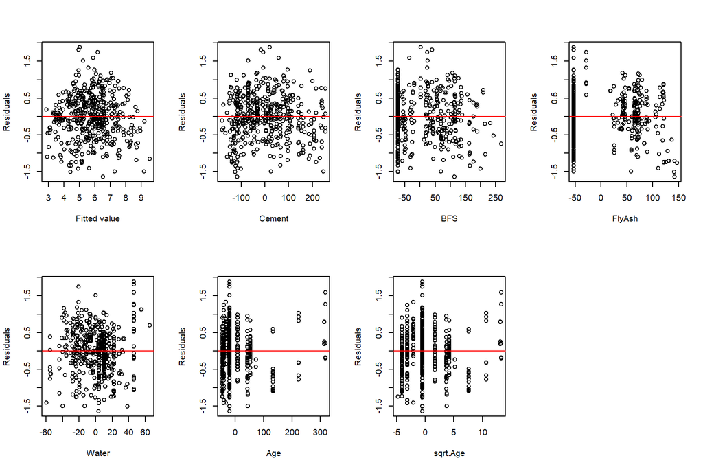

# BP test

```
## [1] 0.601361
```

```
## [1] 3.841459
```

# Lack-of-fit test

我們針對 $m_3$ 進行 LOF

```
## [1] 0.9637876
```

```
## [1] 1.724064
```

```
## [1] 3.833234
```

```
## [1] 4.141546
```

## Hypotheses

- $H_0: E(\sqrt{CCS}) = Cement + BFS + FlyAsh + Water + Age + \sqrt{Age}$
- $H_1: E(\sqrt{CCS}) \neq Cement + BFS + FlyAsh + Water + Age + \sqrt{Age}$

## Parameters

- c: 14, 為變數 Cement, BFS, FlyAsh, Water 以及 Age 維持同樣 level, 且 CCS 不同值的組數
- n: 29, 這 14 組總共有 29 筆觀察值, $\sum_{j=1}^{c=14} n_j=n=29$
- p: 7, 共 6 個變數加上 1 個截距項
- $\alpha$: 0.01

將上述變量代進下列公式計算$F^*$

- $F^* = \dfrac{SSLF}{c-p} \div \dfrac{SSPE}{n-c} = \dfrac{MSLF}{MSPE} = 3.83$
- $F_{1-\alpha,c-p,n-c} = 4.14$

由於 $F^* \leq F_{1-\alpha,c-p,n-c}$，故我們接受$H_0$.

# The Bonferroni joint confidence intervals

預測模型 $m_3$ 的係數 $\beta_0, \beta_1, ..., \beta_6$ 的聯合信賴區間。

|  | Lower bound | Upper bound |
| --- | --- | --- |
| beta_0 | 5.7405665 | 5.8861276 |
| beta_1 | 0.0087341 | 0.0104877 |
| beta_2 | 0.0066406 | 0.0087456 |
| beta_3 | 0.0048596 | 0.0079918 |
| beta_4 | -0.0199464 | -0.0127239 |
| beta_5 | -0.0261012 | -0.0188070 |
| beta_6 | 0.5402683 | 0.6701593 |